# COMP_2_CROSBY

Amanda Crosby

2023-11-11

# Part A: Conceptual Questions

## A1.

Authors support the claim that it is unethical to include outliers without reporting or removing them for many reasons. One reason is that the addition of the outlier affects the conclusions in such way that the findings no longer represent the majority of the data. As practitioners of science, one should run two models (one with the outliers and one without). If the model changes drastically, one should consider removing the outliers.

## A2.

a=.988, b=.367, c=3.65 indirect effect = a*b = .988 x .367 = 0.363 direct effect = c - ab = 3.65 - 0.363 = 3.287

## A3.

Based on the information given, you can not conclude that the data are consistent with the hypothesized mediation model. This is because condition four requires the effect of x on y must be smaller when controlling for m. Considering the confidence interval contains 0, therefore the estimate is not significantly different than 0 and condition four is not met.

## A4.

The Sobel test is problematic because it assumes that path a and path b are independent of each other, which may not be the case. The advantage of using a non-parametric bootstrapping method is because it does not assume anything about the distributions and can be applied to smaller samples more accurately.

## A5.

The term “direct effect” might be misleading because there are possible other mediators that can explain the residual variance. In multiple mediation, the direct effect would be the effect of X on Y without M1 or M2.

## A6.

### a.

False

### b.

False

## A7.

Comparing a model with 5 predictors to a model with 3 predictors is not the most useful because you do not know which of the two predictors added are explaining more of the variance.

## A8.

### a.

False

### b.

False

## A9.

### a.

False

### b.

False

# Part B: Data Analysis

## B1.

One possible research question you could address with this dataset is does the amount of resources at home and school affect overall math scores. Another question is does the amount of resources affect how students like math? Lastly you could ask if the global region has an affect on resources.

## B2.

Since the study does not include manipulation of variables, this study is correlational. It is identifying association between variables (resources, math scores, etc.).

## B3.

```r
timss <- read.csv("timss.csv") %>% clean_names(case = "snake")
summary(timss)
```

```
##    country          overall_math_score  math_knowing   math_applying
##  Length:58          Min.   :297.0      Min.   :302.0   Min.   :286.0
##  Class :character   1st Qu.:480.2      1st Qu.:477.5   1st Qu.:483.5
##  Mode  :character   Median :515.0      Median :510.5   Median :516.5
##                     Mean   :501.1      Mean   :503.4   Mean   :505.4
##                     3rd Qu.:534.5      3rd Qu.:535.2   3rd Qu.:536.2
##                     Max.   :625.0      Max.   :640.0   Max.   :626.0
##                                        NA's   :2       NA's   :2
##  math_reasoning  students_conf_math students_like_math school_resources
##  Min.   :272.0   Min.   : 9.00      Min.   : 8.90      Min.   : 7.500
##  1st Qu.:477.8   1st Qu.: 9.70      1st Qu.: 9.50      1st Qu.: 9.425
##  Median :511.5   Median :10.00      Median : 9.90      Median :10.200
##  Mean   :503.2   Mean   :10.02      Mean   :10.04      Mean   :10.081
##  3rd Qu.:536.2   3rd Qu.:10.30      3rd Qu.:10.50      3rd Qu.:10.800
##  Max.   :614.0   Max.   :11.10      Max.   :11.80      Max.   :12.300
##  NA's   :2
##  home_resources   global_region      gni_per_capita  percent_girls
##  Min.   : 6.900   Length:58          Min.   : 1570   Min.   :45.00
##  1st Qu.: 9.425   Class :character   1st Qu.: 9140   1st Qu.:48.00
##  Median :10.300   Mode  :character   Median :23180   Median :49.00
##  Mean   :10.083                      Mean   :29088   Mean   :48.95
##  3rd Qu.:10.800                      3rd Qu.:48110   3rd Qu.:50.00
##  Max.   :11.900                      Max.   :82430   Max.   :52.00
##  NA's   :4                           NA's   :1
```

```r
describe(timss)
```

```
##                    vars  n     mean       sd  median  trimmed      mad    min
## country*              1 58    29.50    16.89    29.5    29.50    21.50    1.0
## overall_math_score    2 58   501.10    64.40   515.0   505.83    41.51  297.0
## math_knowing          3 56   503.43    64.42   510.5   506.89    41.51  302.0
## math_applying         4 56   505.43    63.27   516.5   510.80    37.06  286.0
## math_reasoning        5 56   503.23    62.09   511.5   508.91    44.48  272.0
## students_conf_math    6 58    10.02     0.51    10.0    10.02     0.44    9.0
## students_like_math    7 58    10.04     0.71     9.9    10.00     0.74    8.9
## school_resources      8 58    10.08     0.99    10.2    10.11     0.89    7.5
## home_resources        9 54    10.08     1.00    10.3    10.16     0.82    6.9
## global_region*       10 58     2.74     0.87     3.0     2.65     0.00    1.0
## gni_per_capita       11 57 29088.07 21635.02 23180.0 27698.51 27131.58 1570.0
## percent_girls        12 58    48.95     1.30    49.0    48.98     1.48   45.0
##                        max   range  skew kurtosis      se
## country*              58.0    57.0  0.00    -1.26    2.22
## overall_math_score   625.0   328.0 -0.93     1.15    8.46
## math_knowing         640.0   338.0 -0.78     1.36    8.61
## math_applying        626.0   340.0 -1.25     2.62    8.46
## math_reasoning       614.0   342.0 -1.23     2.37    8.30
## students_conf_math    11.1     2.1  0.02    -0.55    0.07
## students_like_math    11.8     2.9  0.57    -0.59    0.09
## school_resources      12.3     4.8 -0.38    -0.43    0.13
## home_resources        11.9     5.0 -0.79     0.52    0.14
## global_region*         6.0     5.0  1.14     2.86    0.11
## gni_per_capita     82430.0 80860.0  0.45    -1.07 2865.63
## percent_girls         52.0     7.0 -0.33     0.74    0.17
```

There are a few missing data values.

## B4.

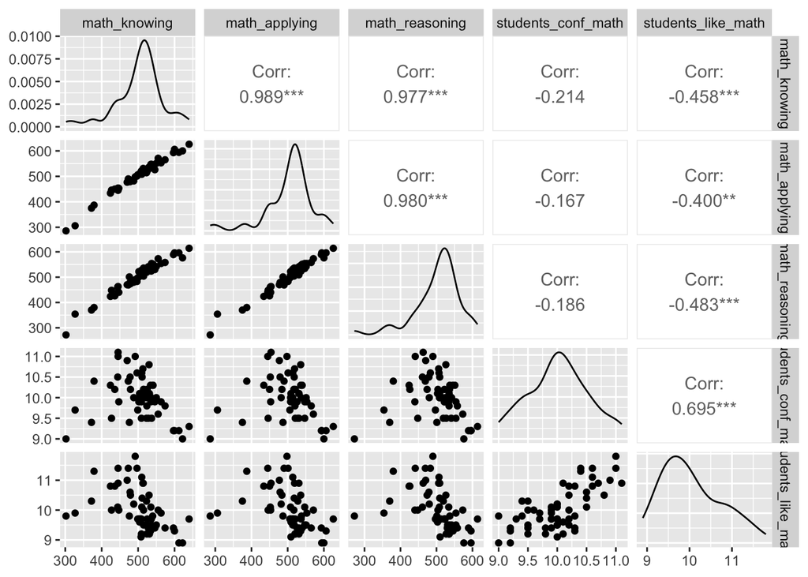

```r
GGally::ggpairs(timss %>% select(math_knowing, math_applying, math_reasoning,
                                 students_conf_math, students_like_math))
```

## B5.

The focal predictor is liking math, the covariate is gender, and the outcome is math score. The compact model would be: overall_math_score = b0 + b1students_liking_math. The augmented model would be: overall_math_score = b0 + b1students_liking_math + b2percent_girls

## B6.

```r
m1 <- lm(overall_math_score ~ students_like_math + percent_girls, data = timss)
summary(m1)
```

```
##
## Call:
## lm(formula = overall_math_score ~ students_like_math + percent_girls,
##     data = timss)
##
## Residuals:
##      Min       1Q   Median       3Q      Max
## -205.435  -16.225    4.736   34.547  109.170
##
## Coefficients:
##                    Estimate Std. Error t value Pr(>|t|)
## (Intercept)         462.688    303.591   1.524 0.133226
## students_like_math  -41.317     10.726  -3.852 0.000308 ***
## percent_girls         9.264      5.811   1.594 0.116611
## ---
## Signif. codes:  0 '***' 0.001 '**' 0.01 '*' 0.05 '.' 0.1 ' ' 1
##
## Residual standard error: 57.18 on 55 degrees of freedom
## Multiple R-squared:  0.2393, Adjusted R-squared:  0.2117
## F-statistic: 8.652 on 2 and 55 DF,  p-value: 0.0005409
```

b0 is 462.69 - this is what our model predicts overall math score to be for a country with a score of 0 on students liking math and have 0% girls. b1 is -41.32 - for every one unit increase in students_like_math, our model predicts a 41.32 unit decrease in overall_math_scores. b2 is 9.26 - for every one unit increase in percent_girls, our model predicts a 9.26 unit increase in overall_math_scores.

## B7.

```r
car::Anova(m1, type = 3) %>% eta_squared()
```

```
## # Effect Size for ANOVA (Type III)
##
## Parameter          | Eta2 (partial) |       95% CI
## --------------------------------------------------
## students_like_math |           0.21 | [0.07, 1.00]
## percent_girls      |           0.04 | [0.00, 1.00]
##
## - One-sided CIs: upper bound fixed at [1.00].
```

np2 for students_like_math is .21 and delta R^2 is .212. np2 for percent_girls is .04 and delta R^2 is .023.

## B8.

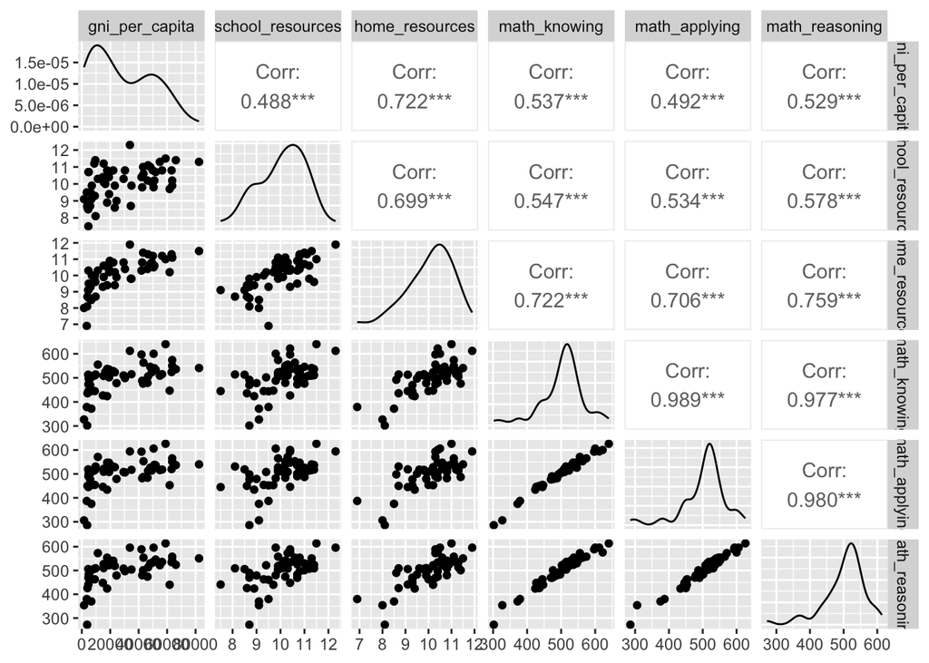

```r
GGally::ggpairs(timss %>% select(gni_per_capita, school_resources,
                                 home_resources, math_knowing, math_applying,
                                 math_reasoning))
```

## B9.

There is a moderate positive correlation between gross national income and math knowing. There is a moderate positive correlation between school resources and math knowing. Lastly, there is a strong positive correlation between home resources and math knowing.

## B10.

The focal predictor is gross national income per capita. The covariates are school and home resources. The compact model would be: overall_math_score = b0 + b1gni_per_capita and the augmented model would be: overall_math_score = b0 + b1gni_per_capita + b2school_resources + b3home_resources

## B11

```r
timss <- na.omit(timss)
timss$gni_per_capita_c <- timss$gni_per_capita - mean(timss$gni_per_capita)
timss$school_resources_c <- timss$school_resources - mean(timss$school_resources)
timss$home_resources_c <- timss$home_resources - mean(timss$home_resources)

m2 <- lm(overall_math_score ~ gni_per_capita_c + school_resources_c +
            home_resources_c, data = timss)
summary(m2)
```

```
##
## Call:
## lm(formula = overall_math_score ~ gni_per_capita_c + school_resources_c +
##     home_resources_c, data = timss)
##
## Residuals:
##      Min       1Q   Median       3Q      Max
## -112.385  -27.251   -1.786   19.208   90.079
##
## Coefficients:
##                      Estimate Std. Error t value Pr(>|t|)
## (Intercept)         5.008e+02  6.100e+00  82.093  < 2e-16 ***
## gni_per_capita_c   -1.571e-04  4.184e-04  -0.376 0.708957
## school_resources_c  4.071e+00  8.896e+00   0.458 0.649360
## home_resources_c    4.485e+01  1.099e+01   4.081 0.000172 ***
## ---
## Signif. codes:  0 '***' 0.001 '**' 0.01 '*' 0.05 '.' 0.1 ' ' 1
##
## Residual standard error: 43.56 on 47 degrees of freedom
## Multiple R-squared:  0.5461, Adjusted R-squared:  0.5171
## F-statistic: 18.85 on 3 and 47 DF,  p-value: 3.627e-08
```

b0 is 500.8, this is what our model predicts overall_math_score to be for a country that is average in GNI, school resources, and home resources. b1 is -1.571e-04 - for every unit increase in GNI, our model predicts a 1.571e-04 unit decrease in overall math scores while controlling for school and home resources. b2 is 4.071 - for every unit increase in school resources, our model predicts a 4.07 unit increase in math scores while controlling for home resources and GNI. b3 is 44.85 - for every unit increase in home resources, our model predicts a 44.85 unit increase in overall math scores while controlling for school resources and GNI.

## B12.

Based on the information I have, I think there might be an issue with multicollinearity especially looking at the correlation matrix. If multicollinearity occurs, the standard errors generally increase.

## B13.

```r
vif(m2)
```

```
##   gni_per_capita_c school_resources_c   home_resources_c
##           2.139691           1.990981           3.323205
```

The VIF cutoff is typically 10. In this model, none of the predictors exceed that cutoff.

## B14.

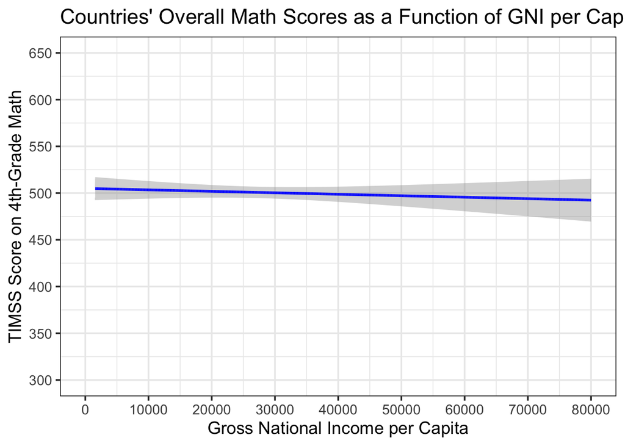

```r
m_graph <- lm(overall_math_score ~ gni_per_capita + school_resources + home_resources, data = timss)
d_graph <- expand.grid(gni_per_capita = seq(min(timss$gni_per_capita, na.rm = TRUE),
                                            max(timss$gni_per_capita, na.rm = TRUE),
                                            length.out = max(timss$gni_per_capita, na.rm = TRUE) - min(timss$gni_per_capita, na.rm = TRUE) + 1),
                       school_resources = mean(timss$school_resources, na.rm = TRUE),
                       home_resources = mean(timss$home_resources, na.rm = TRUE)
)
d_graph <- ggplotPredict(m_graph, d_graph)

ggplot(timss, aes(x = gni_per_capita, y = overall_math_score)) +
  geom_smooth(data = d_graph, stat = "identity", aes(y = Predicted, ymin = CILo, ymax = CIHi), color = "blue", span = 0.1) +
  theme_bw(base_size = 14) +
  labs(x = "Gross National Income per Capita", y = "TIMSS Score on 4th-Grade Math",
       title = "Countries' Overall Math Scores as a Function of GNI per Capita") +
    scale_x_continuous(breaks = seq(0, 80000, by = 10000), limits = c(0, 80000)) +
    scale_y_continuous(breaks = seq(300, 650, by = 50), limits = c(300, 650))
```

## B15.

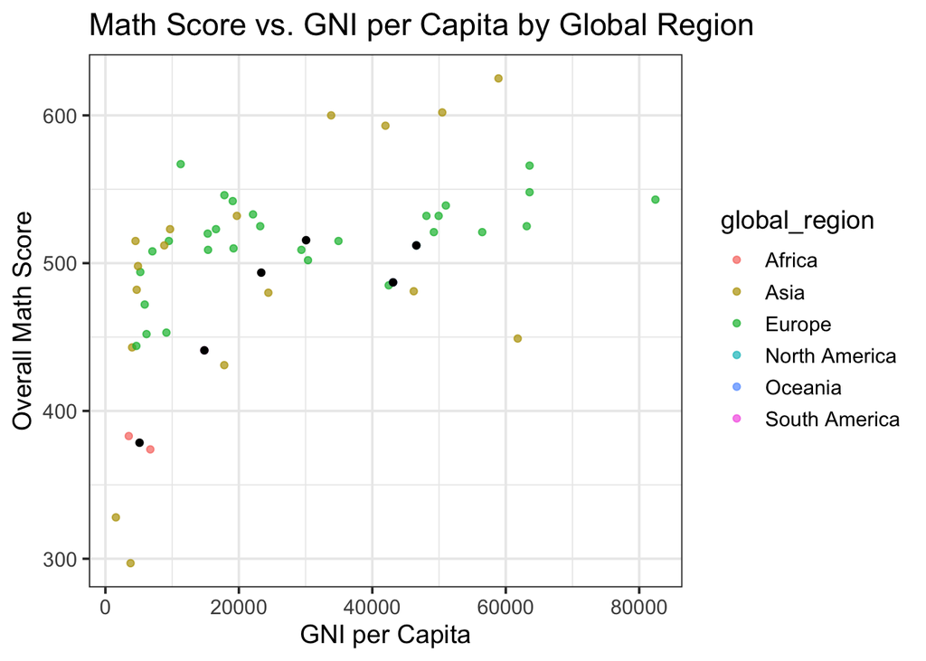

```r
region_averages <- timss %>%
  group_by(global_region) %>%
  summarize(avg_math_score = mean(overall_math_score, na.rm = TRUE),
            avg_gni_per_capita = mean(gni_per_capita, na.rm = TRUE))

ggplot(timss, aes(x = gni_per_capita, y = overall_math_score)) +
  geom_point(aes(color = global_region), alpha = 0.7) +
  geom_point(data = region_averages, aes(x = avg_gni_per_capita, y = avg_math_score)) +
  labs(x = "GNI per Capita", y = "Overall Math Score",
       title = "Math Score vs. GNI per Capita by Global Region") +
  theme_bw(base_size = 14)
```

# Part C: Data Analysis 2

## C1.

```r
integer <- read.csv("integer_fluency.csv") %>% clean_names(case = "snake")
describe(integer)
```

```
##                  vars  n   mean    sd median trimmed   mad min max range  skew
## sub_id              1 62  48.29 19.32   48.5   48.50 24.46  11  80    69 -0.08
## age_months          2 62 137.29  7.90  134.5  136.86  8.15 122 156    34  0.42
## grade_level         3 62   1.73  0.77    2.0    1.66  1.48   1   3     2  0.50
## gender              4 62   0.60  0.53    1.0    0.60  0.00   0   2     2 -0.05
## integer_fluency     5 62  16.05  6.73   16.0   16.58  7.41   0  25    25 -0.46
## ma_1                6 62   1.39  0.64    1.0    1.26  0.00   1   3     2  1.36
## ma_2                7 62   2.10  0.92    2.0    2.02  1.48   1   5     4  0.69
## ma_3                8 62   1.16  0.41    1.0    1.06  0.00   1   3     2  2.46
## ma_4                9 62   2.15  1.02    2.0    2.02  1.48   1   5     4  0.80
## ma_5               10 62   2.68  1.08    3.0    2.66  1.48   1   5     4  0.27
## ma_6               11 62   1.47  0.86    1.0    1.26  0.00   1   5     4  2.13
## ma_7               12 62   1.16  0.49    1.0    1.04  0.00   1   4     3  3.77
## ma_8               13 62   2.26  0.92    2.0    2.20  1.48   1   4     3  0.22
## ma_9               14 62   1.56  0.80    1.0    1.44  0.00   1   4     3  1.11
## additive_inverse   15 62   0.40  0.98    0.0    0.14  0.00   0   4     4  2.71
## precise_language   16 62   3.00  1.33    4.0    3.24  0.00   0   4     4 -1.07
## working_memory     17 62   4.53  1.99    4.0    4.54  1.48   0   9     9  0.00
##                  kurtosis   se
## sub_id              -1.21 2.45
## age_months          -0.90 1.00
## grade_level         -1.19 0.10
## gender              -1.30 0.07
## integer_fluency     -0.60 0.86
## ma_1                 0.62 0.08
## ma_2                 0.28 0.12
## ma_3                 5.58 0.05
## ma_4                 0.23 0.13
## ma_5                -0.75 0.14
## ma_6                 4.49 0.11
## ma_7                16.84 0.06
## ma_8                -0.86 0.12
## ma_9                 0.03 0.10
## additive_inverse     6.62 0.12
## precise_language    -0.10 0.17
## working_memory      -0.46 0.25
```

There does not seem to be any missing data.

## C2.

```r
integer %>% select(ma_1, ma_2, ma_3, ma_4, ma_5, ma_6, ma_7, ma_8, ma_9) %>% psych::alpha()
```

```
##
## Reliability analysis
## Call: psych::alpha(x = .)
##
##   raw_alpha std.alpha G6(smc) average_r S/N   ase mean   sd median_r
##       0.76      0.77    0.79      0.27 3.3 0.042  1.8 0.48     0.24
##
##     95% confidence boundaries
##          lower alpha upper
## Feldt     0.66  0.76  0.84
## Duhachek  0.68  0.76  0.85
##
##  Reliability if an item is dropped:
##      raw_alpha std.alpha G6(smc) average_r S/N alpha se var.r med.r
## ma_1      0.73      0.73    0.75      0.25 2.7    0.049 0.017  0.22
## ma_2      0.72      0.73    0.75      0.25 2.7    0.049 0.017  0.22
## ma_3      0.76      0.76    0.77      0.28 3.1    0.044 0.020  0.22
## ma_4      0.69      0.71    0.71      0.23 2.4    0.056 0.010  0.21
## ma_5      0.74      0.74    0.77      0.27 2.9    0.047 0.021  0.21
## ma_6      0.76      0.76    0.78      0.28 3.1    0.043 0.023  0.26
## ma_7      0.76      0.76    0.78      0.29 3.2    0.044 0.022  0.28
## ma_8      0.74      0.75    0.76      0.27 3.0    0.047 0.018  0.24
## ma_9      0.75      0.75    0.77      0.28 3.1    0.043 0.023  0.26
##
##  Item statistics
##       n raw.r std.r r.cor r.drop mean   sd
## ma_1 62  0.67  0.67  0.63   0.57  1.4 0.64
## ma_2 62  0.68  0.65  0.62   0.53  2.1 0.92
## ma_3 62  0.42  0.52  0.44   0.34  1.2 0.41
## ma_4 62  0.80  0.77  0.80   0.68  2.1 1.02
## ma_5 62  0.65  0.59  0.52   0.47  2.7 1.08
## ma_6 62  0.51  0.51  0.40   0.34  1.5 0.86
## ma_7 62  0.41  0.48  0.36   0.31  1.2 0.49
## ma_8 62  0.62  0.57  0.51   0.46  2.3 0.92
## ma_9 62  0.50  0.53  0.44   0.34  1.6 0.80
##
## Non missing response frequency for each item
##         1    2    3    4    5 miss
## ma_1 0.69 0.23 0.08 0.00 0.00    0
## ma_2 0.27 0.44 0.23 0.05 0.02    0
## ma_3 0.85 0.13 0.02 0.00 0.00    0
## ma_4 0.29 0.40 0.21 0.06 0.03    0
## ma_5 0.13 0.35 0.27 0.19 0.05    0
## ma_6 0.69 0.21 0.05 0.03 0.02    0
## ma_7 0.87 0.11 0.00 0.02 0.00    0
## ma_8 0.23 0.39 0.29 0.10 0.00    0
## ma_9 0.61 0.23 0.15 0.02 0.00    0
```

The Cronbach’s alpha of this scale is 0.76. The cutoff for alpha scores is .7, and since our score is above that I would say this scale is reliable.

## C3.

```r
integer$math_anxiety_total <- varScore(integer,
                                       Forward = c("ma_1","ma_2", "ma_3", "ma_4",
                                                   "ma_5", "ma_6", "ma_7", "ma_8",
                                                   "ma_9"), MaxMiss = 0.25)/9
```

## C4.

```r
integer <- integer[integer$gender != "2",]
```

## C5.

```r
m3 <- lm(integer_fluency ~ age_months + grade_level + gender + math_anxiety_total +
           additive_inverse, data = integer)
summary(m3)
```

```
##
## Call:
## lm(formula = integer_fluency ~ age_months + grade_level + gender +
##     math_anxiety_total + additive_inverse, data = integer)
##
## Residuals:
##      Min       1Q   Median       3Q      Max
## -10.7350  -3.1855  -0.2744   3.7932  10.2172
##
## Coefficients:
##                    Estimate Std. Error t value Pr(>|t|)
## (Intercept)        -14.7922    18.2790  -0.809   0.4219
## age_months           0.2386     0.1481   1.611   0.1130
## grade_level          2.1090     1.5660   1.347   0.1836
## gender               2.0368     1.4737   1.382   0.1725
## math_anxiety_total  -3.8643     1.4842  -2.604   0.0118 *
## additive_inverse     0.2515     0.7380   0.341   0.7345
## ---
## Signif. codes:  0 '***' 0.001 '**' 0.01 '*' 0.05 '.' 0.1 ' ' 1
##
## Residual standard error: 5.457 on 55 degrees of freedom
## Multiple R-squared:  0.3935, Adjusted R-squared:  0.3384
## F-statistic: 7.137 on 5 and 55 DF,  p-value: 3.305e-05
```

The coefficient for age is 0.239 - for every month older a child is, our model predicts a 0.239 unit increase in integer fluency controlling for other factors. This predictor is not statistically significant. The coefficient for grade level is 2.11 - for every grade increase, our model predicts a 2.11 unit increase in integer fluency controlling for other factors. This predictor is not statistically significant. The coefficient for gender is 2.04 - for every unit increase on gender (female to male), our model predicts a 2.04 unit increase in integer fluency controlling for other factors. This predictor is not statistically significant. The coefficient for additive inverse is 0.25 - for every time a participant described the affitive inverse principal to explain their solutions, our model predicts a 0.25 unit increase in integer fluency controlling for other factors. This predictor is not statistically significant. The coefficient for math anxiety is -3.86 - for every unit increase in anxiety, our model predicts a 3.86 unit decrease in integer fluency controlling for other factors. This predictor is statistically significant.

## C6.

```r
# x: gender, y: integer fluency, m: math anxiety
# Cond 1:
m4 <- lm(integer_fluency ~ gender, data = integer)
summary(m4)
```

```
##
## Call:
## lm(formula = integer_fluency ~ gender, data = integer)
##
## Residuals:
##      Min       1Q   Median       3Q      Max
## -17.6286  -3.6286   0.3714   4.3714  11.3846
##
## Coefficients:
##             Estimate Std. Error t value Pr(>|t|)
## (Intercept)   13.615      1.266   10.75 1.59e-15 ***
## gender         4.013      1.672    2.40   0.0196 *
## ---
## Signif. codes:  0 '***' 0.001 '**' 0.01 '*' 0.05 '.' 0.1 ' ' 1
##
## Residual standard error: 6.458 on 59 degrees of freedom
## Multiple R-squared:  0.08897,    Adjusted R-squared:  0.07353
## F-statistic: 5.762 on 1 and 59 DF,  p-value: 0.01955
```

```r
# Cond 2:
m5 <- lm(math_anxiety_total ~ gender, data = integer)
summary(m5)
```

```
##
## Call:
## lm(formula = math_anxiety_total ~ gender, data = integer)
##
## Residuals:
##     Min      1Q  Median      3Q     Max
## -0.7682 -0.3238 -0.1016  0.2318  1.4540
##
## Coefficients:
##             Estimate Std. Error t value Pr(>|t|)
## (Intercept)  1.79487    0.09486  18.921   <2e-16 ***
## gender      -0.02662    0.12523  -0.213    0.832
## ---
## Signif. codes:  0 '***' 0.001 '**' 0.01 '*' 0.05 '.' 0.1 ' ' 1
##
## Residual standard error: 0.4837 on 59 degrees of freedom
## Multiple R-squared:  0.0007651,  Adjusted R-squared:  -0.01617
## F-statistic: 0.04518 on 1 and 59 DF,  p-value: 0.8324
```

```r
# Cond 3:
m6 <- lm(integer_fluency ~ math_anxiety_total + gender, data = integer)
summary(m6)
```

```
##
## Call:
## lm(formula = integer_fluency ~ math_anxiety_total + gender, data = integer)
##
## Residuals:
##      Min       1Q   Median       3Q      Max
## -14.6275  -4.1335   0.2017   4.1371  12.1665
##
## Coefficients:
##                    Estimate Std. Error t value Pr(>|t|)
## (Intercept)          20.457      3.254   6.286 4.58e-08 ***
## math_anxiety_total   -3.812      1.680  -2.269   0.0270 *
## gender                3.912      1.617   2.420   0.0187 *
## ---
## Signif. codes:  0 '***' 0.001 '**' 0.01 '*' 0.05 '.' 0.1 ' ' 1
##
## Residual standard error: 6.242 on 58 degrees of freedom
## Multiple R-squared:  0.1632, Adjusted R-squared:  0.1344
## F-statistic: 5.657 on 2 and 58 DF,  p-value: 0.005694
```

## C8.

```r
# x: age, y: integer_fluency, m: precise_language

# Cond 1:
m7 <- lm(integer_fluency ~ age_months, data = integer)
summary(m7) # p-value: 3.742e-05
```

```
##
## Call:
## lm(formula = integer_fluency ~ age_months, data = integer)
##
## Residuals:
##     Min      1Q  Median      3Q     Max
## -13.290  -4.005   0.281   3.995  12.567
##
## Coefficients:
##             Estimate Std. Error t value Pr(>|t|)
## (Intercept) -42.8511    13.1993  -3.246  0.00193 **
## age_months    0.4286     0.0961   4.460 3.74e-05 ***
## ---
## Signif. codes:  0 '***' 0.001 '**' 0.01 '*' 0.05 '.' 0.1 ' ' 1
##
## Residual standard error: 5.851 on 59 degrees of freedom
## Multiple R-squared:  0.2521, Adjusted R-squared:  0.2394
## F-statistic: 19.89 on 1 and 59 DF,  p-value: 3.742e-05
```

```r
car::Anova(m7, type = 3) %>% eta_squared()
```

```
## For one-way between subjects designs, partial eta squared is equivalent
##   to eta squared. Returning eta squared.
```

```
## # Effect Size for ANOVA
##
## Parameter  | Eta2 |       95% CI
## --------------------------------
## age_months | 0.25 | [0.11, 1.00]
##
## - One-sided CIs: upper bound fixed at [1.00].
```

```r
# Cond 2:
m8 <- lm(precise_language ~ age_months, data = integer)
summary(m8) #p-value: 0.03099
```

```
##
## Call:
## lm(formula = precise_language ~ age_months, data = integer)
##
## Residuals:
##     Min      1Q  Median      3Q     Max
## -2.9305 -0.7895  0.4589  0.9286  1.7272
##
## Coefficients:
##             Estimate Std. Error t value Pr(>|t|)
## (Intercept) -3.45802    2.91937  -1.185    0.241
## age_months   0.04697    0.02125   2.210    0.031 *
## ---
## Signif. codes:  0 '***' 0.001 '**' 0.01 '*' 0.05 '.' 0.1 ' ' 1
##
## Residual standard error: 1.294 on 59 degrees of freedom
## Multiple R-squared:  0.07646,    Adjusted R-squared:  0.0608
## F-statistic: 4.884 on 1 and 59 DF,  p-value: 0.03099
```

```r
car::Anova(m8, type = 3) %>% eta_squared()
```

```
## For one-way between subjects designs, partial eta squared is equivalent
##   to eta squared. Returning eta squared.
```

```
## # Effect Size for ANOVA
##
## Parameter  | Eta2 |       95% CI
## --------------------------------
## age_months | 0.08 | [0.00, 1.00]
##
## - One-sided CIs: upper bound fixed at [1.00].
```

```r
# Cond 3:
m9 <- lm(integer_fluency ~ precise_language + age_months, data = integer)
summary(m9) #p-value: 2.868e-05
```

```
##
## Call:
## lm(formula = integer_fluency ~ precise_language + age_months,
##     data = integer)
##
## Residuals:
##      Min       1Q   Median       3Q      Max
## -10.1177  -4.9456  -0.0985   3.9918  13.0159
##
## Coefficients:
##                   Estimate Std. Error t value Pr(>|t|)
## (Intercept)      -38.78098   13.00555  -2.982 0.004183 **
## precise_language   1.17700    0.57321   2.053 0.044556 *
## age_months         0.37327    0.09738   3.833 0.000314 ***
## ---
## Signif. codes:  0 '***' 0.001 '**' 0.01 '*' 0.05 '.' 0.1 ' ' 1
##
## Residual standard error: 5.698 on 58 degrees of freedom
## Multiple R-squared:  0.3028, Adjusted R-squared:  0.2787
## F-statistic: 12.59 on 2 and 58 DF,  p-value: 2.868e-05
```

```r
car::Anova(m9, type = 3) %>% eta_squared()
```

```
## # Effect Size for ANOVA (Type III)
##
## Parameter        | Eta2 (partial) |       95% CI
## ------------------------------------------------
## precise_language |           0.07 | [0.00, 1.00]
## age_months       |           0.20 | [0.07, 1.00]
##
## - One-sided CIs: upper bound fixed at [1.00].
```

## C9.

```r
medmodel <- '

precise_language ~ A * age_months
integer_fluency ~ CPRIME * age_months + B * precise_language

AB:= A*B # Indirect effect
Total := CPRIME + A*B # Total effect
'
set.seed(123)
fit <- sem(medmodel, data = integer, se = "bootstrap", bootstrap = 1000)
parameterEstimates(fit, ci = TRUE, level = 0.95, boot.ci.type = "perc", zstat = F)
```

```
##                lhs op              rhs  label    est    se ci.lower ci.upper
## 1 precise_language  ~       age_months      A  0.047 0.019    0.014    0.089
## 2  integer_fluency  ~       age_months CPRIME  0.373 0.079    0.218    0.528
## 3  integer_fluency  ~ precise_language      B  1.177 0.761   -0.177    2.725
## 4 precise_language ~~ precise_language         1.620 0.271    1.074    2.117
## 5  integer_fluency ~~  integer_fluency        30.867 4.349   21.130   38.192
## 6       age_months ~~       age_months        60.770 0.000   60.770   60.770
## 7               AB :=              A*B     AB  0.055 0.044   -0.007    0.167
## 8            Total :=       CPRIME+A*B  Total  0.429 0.084    0.269    0.603
```

Path AB has a confidence interval that does include 0. Therefore, the estimate is not significantly different than 0 and condition four is not met.

## C11.

```r
participant_ids <- c(11, 15, 18:28, 30:34, 36:41, 43:54, 56:80)
fake_scores <- sample(1:9, 61, replace = TRUE)
backwards_digit <- data.frame(sub_id = participant_ids, backwards_digit_span = fake_scores)

integer <- integer %>% full_join(backwards_digit) %>% as.data.frame()
```

## C12.

```r
m10 <- lm(integer_fluency ~ backwards_digit_span + age_months, data = integer)
summary(m10)
```

```
##
## Call:
## lm(formula = integer_fluency ~ backwards_digit_span + age_months,
##     data = integer)
##
## Residuals:
##      Min       1Q   Median       3Q      Max
## -13.0758  -3.4095   0.4506   4.1802  12.3326
##
## Coefficients:
##                       Estimate Std. Error t value Pr(>|t|)
## (Intercept)          -46.79295   12.97043  -3.608 0.000644 ***
## backwards_digit_span   0.65292    0.31098   2.100 0.040127 *
## age_months             0.43241    0.09346   4.627 2.13e-05 ***
## ---
## Signif. codes:  0 '***' 0.001 '**' 0.01 '*' 0.05 '.' 0.1 ' ' 1
##
## Residual standard error: 5.689 on 58 degrees of freedom
## Multiple R-squared:  0.3049, Adjusted R-squared:  0.281
## F-statistic: 12.72 on 2 and 58 DF,  p-value: 2.623e-05
```

## C13.

```r
x_hats <- modelCaseAnalysis(m10, Type = "HATVALUES")
```

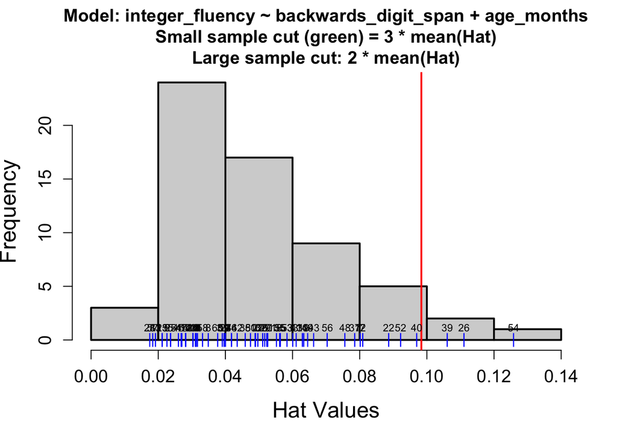

## C14.

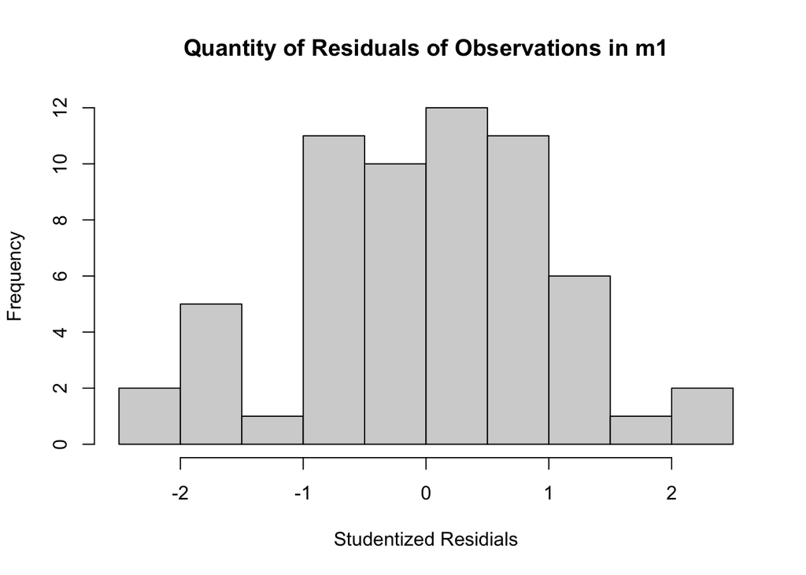

```r
hist(rstudent(m10), xlab = "Studentized Residials",
     main = "Quantity of Residuals of Observations in m1")
```

```r
which(rstudent(m1) < -1)
```

```
## 11 31 36 43 44 47 49 53
## 11 31 36 43 44 47 49 53
```

```r
x_resids <- modelCaseAnalysis(m10, Type = "RESIDUALS")
```

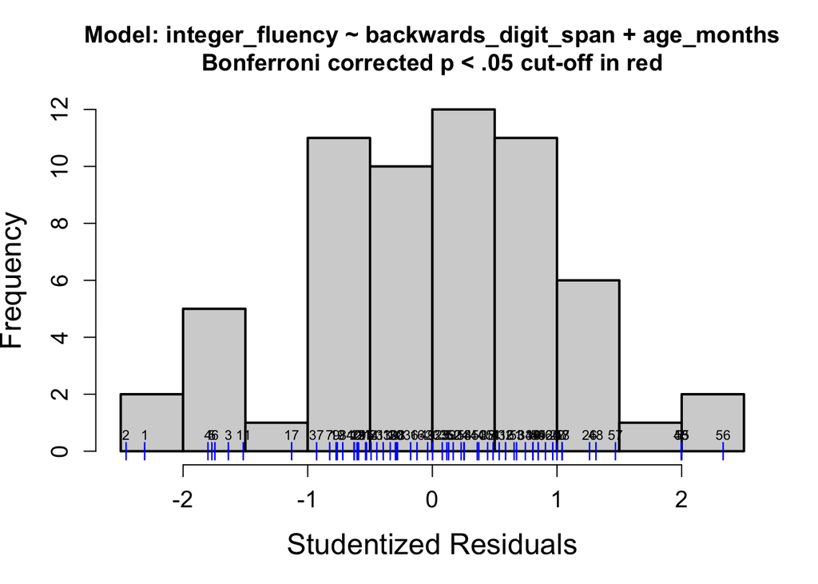

## C15.

```r
x_cooks <- modelCaseAnalysis(m10, Type = "COOKSD")
```

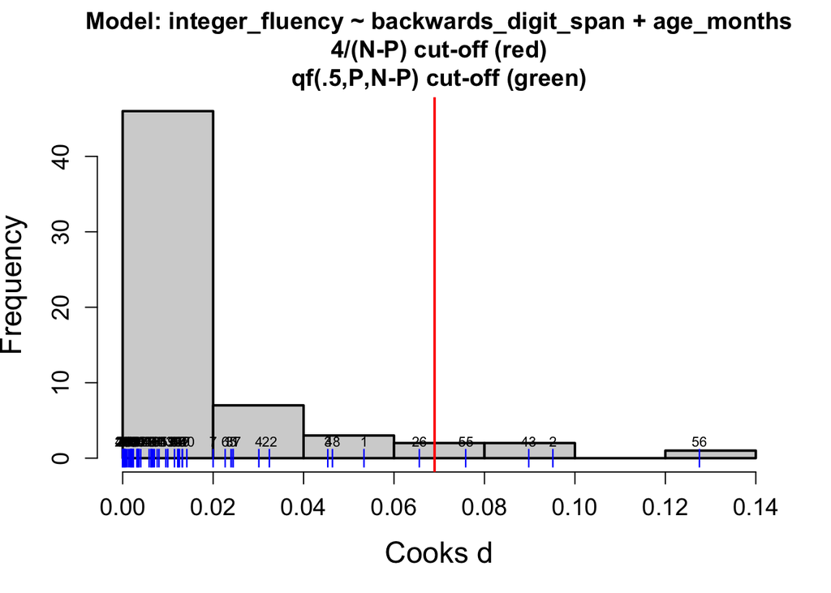

## C16.

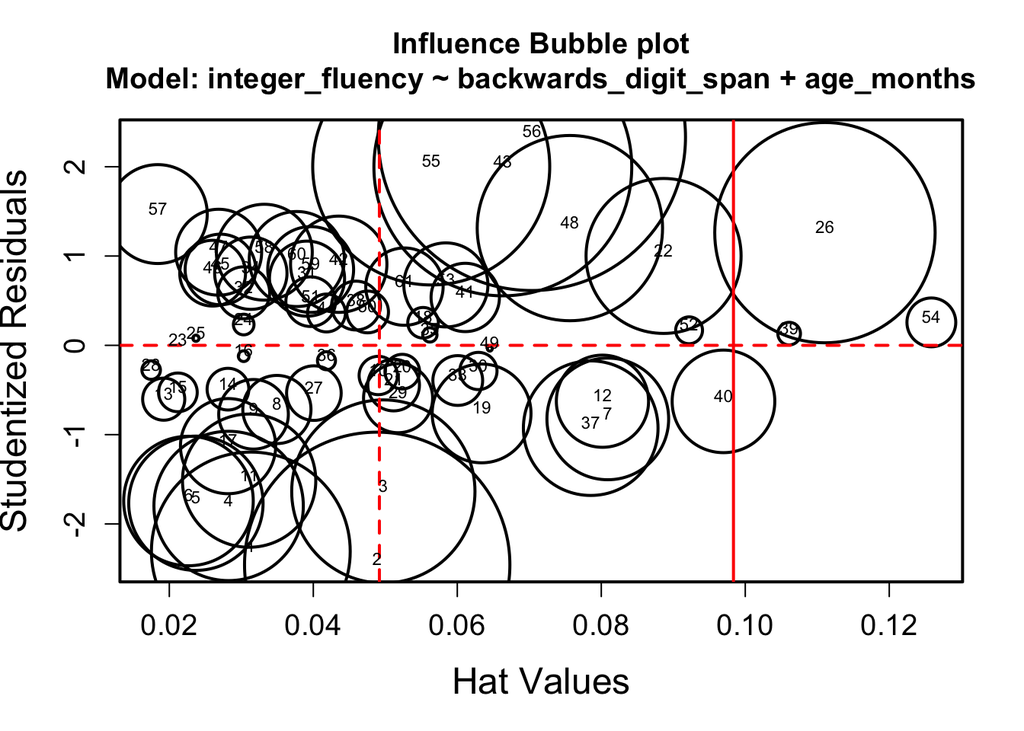

```r
x_infs <- modelCaseAnalysis(m10, Type = "INFLUENCEPLOT")
```

## C17.

I would suggest to remove these participants since they have high influence on the model predictions.

## C18.

```r
integer_new <- integer[integer$sub_id != "15" & integer$sub_id != "47" &
                         integer$sub_id != "41" & integer$sub_id != "69" &
                         integer$sub_id != "62",]
m11 <- lm(integer_fluency ~ backwards_digit_span + age_months, data = integer_new)
summary(m11)
```

```
##
## Call:
## lm(formula = integer_fluency ~ backwards_digit_span + age_months,
##     data = integer_new)
##
## Residuals:
##      Min       1Q   Median       3Q      Max
## -11.9328  -3.3069  -0.0598   3.8529  12.1466
##
## Coefficients:
##                       Estimate Std. Error t value Pr(>|t|)
## (Intercept)          -53.81860   13.06711  -4.119 0.000134 ***
## backwards_digit_span   0.50173    0.30840   1.627 0.109698
## age_months             0.48655    0.09389   5.182 3.49e-06 ***
## ---
## Signif. codes:  0 '***' 0.001 '**' 0.01 '*' 0.05 '.' 0.1 ' ' 1
##
## Residual standard error: 5.348 on 53 degrees of freedom
## Multiple R-squared:  0.3552, Adjusted R-squared:  0.3308
## F-statistic:  14.6 on 2 and 53 DF,  p-value: 8.916e-06
```

```r
summary(m10)
```

```
##
## Call:
## lm(formula = integer_fluency ~ backwards_digit_span + age_months,
##     data = integer)
##
## Residuals:
##      Min       1Q   Median       3Q      Max
## -13.0758  -3.4095   0.4506   4.1802  12.3326
##
## Coefficients:
##                       Estimate Std. Error t value Pr(>|t|)
## (Intercept)          -46.79295   12.97043  -3.608 0.000644 ***
## backwards_digit_span   0.65292    0.31098   2.100 0.040127 *
## age_months             0.43241    0.09346   4.627 2.13e-05 ***
## ---
## Signif. codes:  0 '***' 0.001 '**' 0.01 '*' 0.05 '.' 0.1 ' ' 1
##
## Residual standard error: 5.689 on 58 degrees of freedom
## Multiple R-squared:  0.3049, Adjusted R-squared:  0.281
## F-statistic: 12.72 on 2 and 58 DF,  p-value: 2.623e-05
```